# Test10 overview

ULzii-Utas Narantsatsralt

# General introduction

Test10 is for testing the IndividualRandomConnectivity class which uses a pre-existing connectivity matrix to construct a neural network. In this test, we check the equality between the pre-existing connectivity matrix and constructed connectivity matrix. We show the two connectivity matrices and, the raster plot of two populations.The pre-existing connectivity file needs to be in the INPUT folder.

# Connectivity Matrices

We show two plots: newly constructed matrix used for the simulations and the pre-existing connectivity matrix used as input. The plots are binary connectivity matrix where black dots indicate connection while white dots indicate non-connection. The rows of the connectivity matrix is pre-synaptic neuron and columns are post-synaptic neuron. In this test, we only used pre-existing connectivity matrix from 0 -> 0 population connection and other connections are all randomly connected.

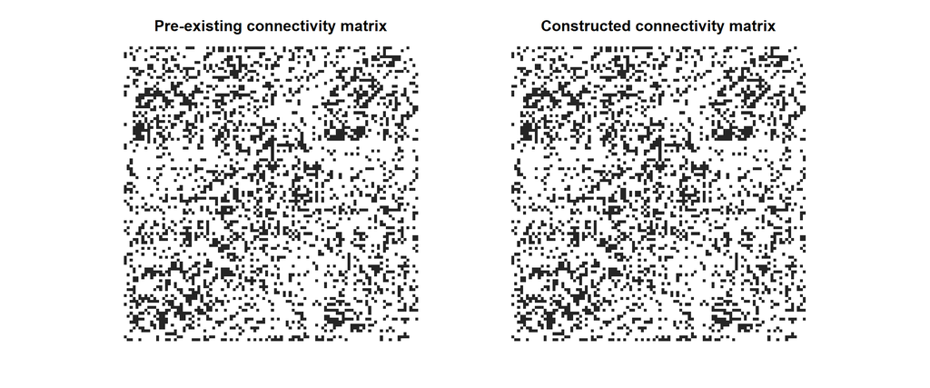

The below code prints a TRUE value if the two matrices are equal and prints FALSE if they are not equal.

is_equal <- all.equal(data_SynapsesConnection_00,data_ConnectivityMatrix_00); str_to_print <- “The two matrices are equal:”;

print(paste(str_to_print, is_equal));

```
## [1] "The two matrices are equal: TRUE"
```

# Raster plot

In the following plots, we show the spike times of individual neurons from two populations. The external input to the two population is increased linearly from 0 to 100.

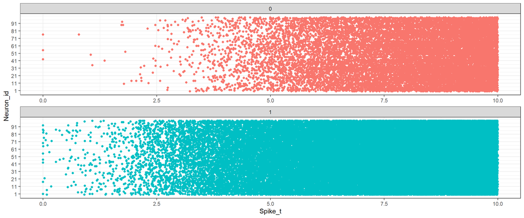